# Cross-Sectional Equity Alpha: From Data Inspection to Backtest

A rigorous, point-in-time research study

Author

Ying Sun

Published

June 2, 2026

Abstract

We build a tradable, dollar-neutral cross-sectional equity alpha from a panel of anonymised security reference data, proprietary signals (`d1`–`d11`) and risk factors (`rf1`–`rf6`) spanning 2010–2017. The study runs end-to-end: data inspection and quality control, point-in-time feature and target construction, model selection on the information coefficient (IC), and a walk-forward out-of-sample backtest. Every step is constructed to be free of look-ahead bias; we are explicit about where rigour matters and quantify the cost of getting it wrong. The final book is an ensemble forecast traded as a risk-factor-neutral, dollar-neutral portfolio.

# 1 Introduction

## 1.1 Objective

The goal is to turn raw, anonymised cross-sectional data into a **tradable equity alpha** and to evaluate it honestly. Concretely, for each security $i$ and trading day $t$ we forecast a forward return, rank securities cross-sectionally, and hold a **dollar-neutral** book (long notional = short notional) rebalanced under realistic trading costs. Success is measured by the **net (after-cost) Sharpe ratio** of the walk-forward out-of-sample equity curve, supported by the forecast’s **information coefficient (IC)**.

Two principles guide the whole study:

1. **No look-ahead.** Every transform that touches a date $t$ uses information available at or before $t$ only — cross-sectional normalisation is computed within a single day, the target is a strictly forward return, and models are trained on trailing windows.
2. **Honest evaluation.** Where a modelling choice can silently leak information (feature selection, hyper-parameter tuning, normalisation statistics), we isolate it and report the *out-of-sample* consequence rather than an in-sample flatter.

## 1.2 Data

The project provides three families of files over **2010–2017** (≈8.8M security-day rows, ~2,000 tradable names per day):

| Family | Contents |
| --- | --- |
| Security reference | `data_date`, `security_id`, `close_price`, `volume`, `group_id` (industry), `in_trading_universe`, `ret1d` (daily return) |
| Signals | `d1`–`d11`, one proprietary signal per file, keyed by `(data_date, security_id)` |
| Risk factors | `rf1`–`rf6`, exposures used for neutralisation |

Only names with `in_trading_universe == "Y"` are holdable; the realised daily return `ret1d` is the raw material for the forecast target.

## 1.3 Pipeline overview

The work is organised as three notebooks, mirrored by the sections of this report:

1. **`data_inspection.ipynb`** — schema, data-quality audit, signal diagnostics (Section 2 below).
2. **`alpha_model.ipynb`** — feature/target engineering, IC-based model selection, and the honest walk-forward forecast.
3. **`portfolio_construction.ipynb`** — alpha → dollar-neutral weights, the backtest engine, risk-factor neutralisation, and performance reporting.

## 1.4 Summary of results

The final model is an **ensemble** (an IC-weighted signal composite blended with a regularised linear model) traded as a **risk-factor-neutral, dollar-neutral** book, rebalanced weekly net of 1 bp. Over the full walk-forward out-of-sample window (2011–2017) it achieves a **net Sharpe of ≈1.4** at ~3.4% annualised volatility. Crucially, this number is reported against an *honest* baseline: removing the look-ahead present in a naïve setup takes a headline Sharpe of ~0.74 down to ~0.40 before our improvements rebuild it on solid ground. The rigour story — what leaked, what we removed, and what we tested and *rejected* — is developed in the modelling and results sections.

# 2 Data Inspection

This section documents the data-quality audit and signal diagnostics that every downstream choice depends on. All figures and tables below are **embedded directly from `data_inspection.ipynb`** so the report and the notebook can never disagree.

## 2.1 Schema and integrity

We first establish the reference panel’s schema, missingness and cardinality, and the value ranges of its numeric columns.

Table 1: Reference data: dtype, missingness, cardinality

|  | dtype | # NaN | % NaN | # unique |
| --- | --- | --- | --- | --- |
| data_date | int32 | 0 | 0 | 2013 |
| security_id | int32 | 0 | 0 | 7876 |
| close_price | float32 | 0 | 0 | 128538 |
| volume | float32 | 0 | 0 | 2515877 |
| group_id | int32 | 0 | 0 | 176 |
| in_trading_universe | category | 0 | 0 | 2 |
| ret1d | float32 | 8854 | 0.101 | 4298865 |
| date | datetime64[us] | 0 | 0 | 2013 |

Source: Data Inspection — Quant Data Project (KTT)

```
     data_date 1: INT min=20,100,104  max=20,131,231 nan_count=0
     data_date 2: INT min=20,140,102  max=20,171,229 nan_count=0
   security_id 1: INT min=77,901  max=1,116,563,801 nan_count=0
   security_id 2: INT min=1,031  max=1,118,042,001 nan_count=0
   close_price 1: FLOAT min=1.0001  max=141768  max_num_decimals=4  max_abs=141768 nan_count=0
   close_price 2: FLOAT min=1.0001  max=4258.6  max_num_decimals=4  max_abs=4258.6 nan_count=0
        volume 1: INT min=0  max=1,864,158,976 nan_count=0
        volume 2: INT min=1  max=618,237,600 nan_count=0
      group_id 1: INT min=10,101,010  max=55,105,010 nan_count=0
      group_id 2: INT min=10,101,010  max=60,102,040 nan_count=0
         ret1d 1: FLOAT min=-0.856203  max=1099  max_num_decimals=8  max_abs=1099 nan_count=3,557
         ret1d 2: FLOAT min=-0.96512  max=100  max_num_decimals=8  max_abs=100 nan_count=5,297
Duplicates in concatenated data: 0
Shape: (8800015, 8)
Date range: 20100104 to 20171229
```

|  | data_date | security_id | close_price | volume | group_id | in_trading_universe | ret1d | date |
| --- | --- | --- | --- | --- | --- | --- | --- | --- |
| 0 | 20100104 | 77901 | 19.99 | 72,728 | 20102010 | N | 0.0256542 | 2010-01-04 |
| 1 | 20100104 | 78001 | 23.77 | 460,537 | 20101010 | Y | 0.0343777 | 2010-01-04 |
| 2 | 20100104 | 78401 | 19.64 | 1.8471e+06 | 20104020 | Y | 0.0282724 | 2010-01-04 |
| 3 | 20100104 | 82901 | 2.8 | 219,545 | 20301010 | N | 0.0606057 | 2010-01-04 |
| 4 | 20100104 | 83501 | 7.9 | 389,291 | 20201060 | N | 0.0851647 | 2010-01-04 |

## 2.2 Trading universe over time

The holdable universe is roughly **45% of all rows** (`Y` = 4.00M vs `N` = 4.80M of 8.8M), and its size drifts materially over the sample — most visibly a **contraction in 2011–2012** that we inspect directly. This matters because the backtest universe, breadth, and turnover all inherit this time-variation.

```
overall in_trading_universe split:
in_trading_universe
N    4796547
Y    4003468
Name: count, dtype: int64
```

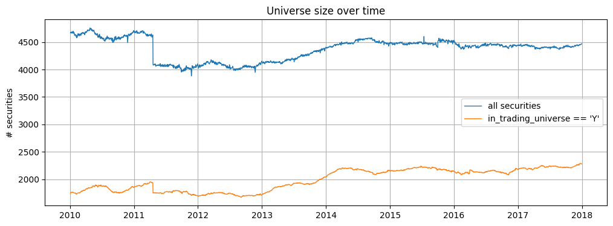

Figure 1: Trading universe size over time (total vs tradable)

```
Largest one-day drops in total universe (2011-2012):
date
2011-04-20   -527
2011-11-25   -119
2012-11-23    -67
2011-09-28    -66
2011-08-16    -54

Drop on 2011-04-20: total 4628 -> 4101, tradable 1934 -> 1749

Excluded on 2011-04-20: 591
Permanently exclucded: 534
Tradable split of removed: {'N': 351, 'Y': 183}
```

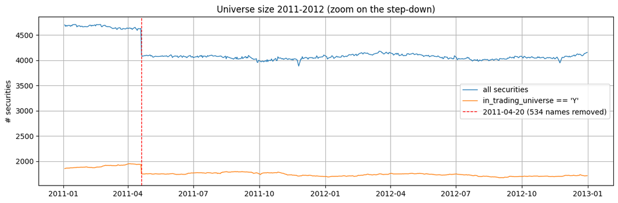

Figure 2: The 2011–2012 contraction in the universe

## 2.3 Returns: distribution and outliers

The daily return `ret1d` is sharply leptokurtic and contaminated by extreme values: across 8.79M observations the standard deviation (0.38) is dominated by tails, with **482 rows of $|r|>1$ and a maximum of +1099** (i.e. +109,900%) — clearly data errors rather than tradable moves. There are 8,854 missing returns.

**ImportantConsequence for the pipeline**

These outliers must be neutralised before they can distort any cumulative or moment-based feature. Downstream we **winsorise `ret1d` cross-sectionally per day** before building the target and any return-based statistic, rather than trusting raw values.

```
count   8.79116e+06
mean    0.000976865
std        0.375352
min        -0.96512
0.1%      -0.173698
1%       -0.0796461
5%       -0.0411564
50%               0
95%       0.0430048
99%       0.0914454
99.9%        0.2415
max           1,099
Name: ret1d, dtype: float64

# NaN ret1d : 8854
# |ret| > 1: 482
# |ret| > 0.5: 2119
```

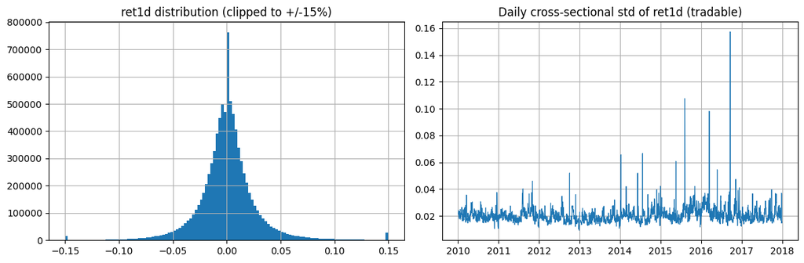

Figure 3: Distribution of daily returns ret1d (clipped for readability)

## 2.4 Forward-return target alignment (no look-ahead)

The forecast target is the **forward return** `ret1d_fwd(i,t) = ret1d(i, t+2)`. The subtlety is that a security can **leave the universe and re-enter months later**: a naïve `shift(-2)` would then pair a pre-gap row with a post-gap return and silently fabricate a “forward” return that spans the hole. We therefore compute the shift **only within chunks of consecutive trading days** (a gap > 5 trading days opens a new chunk), so no return is ever paired across a gap. The output below shows a worked example (security 1031, which exits in 2015-07 and re-enters in 2015-10) and the chunking statistics.

```
Security 1031 before chunking by consecutive trading days:
         data_date  security_id  close_price      volume  group_id in_trading_universe       ret1d       date
6034949   20150714         1031        16.42  8.5381e+06  40202010                   N   -0.105665 2015-07-14
6285099   20151001         1031        10.96 1.10404e+07  40202010                   N   -0.024911 2015-10-01
6289600   20151002         1031        11.04 7.01375e+06  40202010                   N  0.00729917 2015-10-02
6294121   20151005         1031        11.48 5.70252e+06  40202010                   N   0.0398552 2015-10-05
6298656   20151006         1031        11.63 5.16928e+06  40202010                   N   0.0130662 2015-10-06
...            ...          ...          ...         ...       ...                 ...         ...        ...
8777707   20171222         1031        13.35 2.53445e+06  40202010                   Y   0.0175305 2017-12-22
8782163   20171226         1031        13.46 1.73678e+06  40202010                   Y  0.00823981 2017-12-26
8786618   20171227         1031        13.21 1.75017e+06  40202010                   Y  -0.0185737 2017-12-27
8791081   20171228         1031        13.37 1.34298e+06  40202010                   Y   0.0121121 2017-12-28
8795545   20171229         1031        13.32 1.85663e+06  40202010                   Y -0.00373971 2017-12-29

[568 rows x 8 columns]
<bound method NDFrame.head of          data_date  security_id  close_price      volume  group_id in_trading_universe       ret1d       date   ret1d_fwd
6034949   20150714         1031        16.42  8.5381e+06  40202010                   N   -0.105665 2015-07-14         NaN
6285099   20151001         1031        10.96 1.10404e+07  40202010                   N   -0.024911 2015-10-01   0.0398552
6289600   20151002         1031        11.04 7.01375e+06  40202010                   N  0.00729917 2015-10-02   0.0130662
6294121   20151005         1031        11.48 5.70252e+06  40202010                   N   0.0398552 2015-10-05   0.0300947
6298656   20151006         1031        11.63 5.16928e+06  40202010                   N   0.0130662 2015-10-06   0.0100167
...            ...          ...          ...         ...       ...                 ...         ...        ...         ...
8777707   20171222         1031        13.35 2.53445e+06  40202010                   Y   0.0175305 2017-12-22  -0.0185737
8782163   20171226         1031        13.46 1.73678e+06  40202010                   Y  0.00823981 2017-12-26   0.0121121
8786618   20171227         1031        13.21 1.75017e+06  40202010                   Y  -0.0185737 2017-12-27 -0.00373971
8791081   20171228         1031        13.37 1.34298e+06  40202010                   Y   0.0121121 2017-12-28         NaN
8795545   20171229         1031        13.32 1.85663e+06  40202010                   Y -0.00373971 2017-12-29         NaN

[568 rows x 9 columns]>
Securities with reporting gaps > 5 trading days: 2,323
Total gap events: 11,872
Total chunks across all securities: 19,748
Securities with exactly 1 chunk (no gaps): 5,553
Securities with more than 1 chunk (has gaps > 5 trading days): 2,323
forward-return frame (LAG=2): (8800015, 4) | non-null fwd: 8754849
```

**NoteRigour note**

This chunk-aware alignment is the correct, look-ahead-free construction and is the version used for all signal diagnostics in this section. (The modelling section flags a discrepancy where a later notebook overwrites it with the naïve shift — see Section 4.)

## 2.5 Price, volume and industry structure

Basic sanity checks: prices are strictly positive, a single row has non-positive volume, and the `group_id` industry hierarchy resolves to **11 level-I groups** (25 / 72 / 176 at finer levels). No level-I industry is pathologically over- or under-represented, so industry can be used for neutralisation without a degenerate bucket.

```
close_price <= 0 : 0
volume <= 0      : 1
volume == 0      : 1

distinct groups per level:
level_I       11
level_II      25
level_III     72
level_IV     176
dtype: int64

top level-I groups by row count:
level_I
40    1828772
45    1518101
35    1252417
25    1182292
20    1132610
10     546379
15     523598
30     359969
55     221763
50     159302
Name: count, dtype: int64

# unique security_id per level_I:
level_I
40    1721
45    1398
35    1339
25    1082
20     970
10     518
15     502
30     334
60     249
55     164
Name: security_id, dtype: int64

# unique security_id per level_II:
```

[output cut: 25 more lines]

```
Name: security_id, dtype: int64

# unique security_id per level_IV:
level_IV
40101015    680
35201010    549
45101010    294
40102010    253
35202010    247
35101010    238
10102020    222
45103010    214
45201020    166
45301020    157
Name: security_id, dtype: int64
```

## 2.6 Duplicate-key audit

Several signal files violate the `(data_date, security_id)` key. The audit classifies each affected file as *exact-copy* duplicates (safe to drop) versus *conflicting* values (genuinely multi-valued and must be aggregated).

```
data sets with duplicate keys: ['d3', 'd4', 'd9']
```

Table 3: Duplicate-key audit across the signal files d1–d11

| signal | n_raw_rows | dup_key_rows | pct_dup | n_unique_pairs |
| --- | --- | --- | --- | --- |
| d1 | 127266 | 0 | 0 | 127266 |
| d2 | 127266 | 0 | 0 | 127266 |
| d3 | 254532 | 127266 | 50 | 127266 |
| d4 | 254532 | 127266 | 50 | 127266 |
| d5 | 127266 | 0 | 0 | 127266 |
| d6 | 127266 | 0 | 0 | 127266 |
| d7 | 127266 | 0 | 0 | 127266 |
| d8 | 8345449 | 0 | 0 | 8345449 |
| d9 | 16176736 | 8017231 | 49.6 | 8159505 |
| d10 | 3281273 | 0 | 0 | 3281273 |
| d11 | 3281273 | 0 | 0 | 3281273 |

```
d3: dup-key pairs=127,266 | exact-copy=127,266 | conflicting=0 | median rel.diff of twins=0.00%
     collapse=first: median=   0.03  %==100= 0.0  %>100= 0.0
     collapse= mean: median=   0.03  %==100= 0.0  %>100= 0.0
     collapse=  sum: median=   0.01  %==100= 0.0  %>100= 0.0
d4: dup-key pairs=127,266 | exact-copy=127,266 | conflicting=0 | median rel.diff of twins=0.00%
     collapse=first: median=   4.11  %==100= 0.0  %>100= 0.0
     collapse= mean: median=   4.11  %==100= 0.0  %>100= 0.0
     collapse=  sum: median=   7.43  %==100= 0.0  %>100= 0.4
d9: dup-key pairs=8,017,209 | exact-copy=3,716,153 | conflicting=4,301,056 | median rel.diff of twins=1.06%
     collapse=first: median=   8.58  %==100=10.9  %>100= 0.0
     collapse= mean: median=   8.62  %==100=10.7  %>100= 0.0
     collapse=  sum: median=  17.24  %==100= 0.2  %>100=17.6
```

**ImportantResolution**

- **`d3`, `d4`** — 127,266 duplicate-key pairs that are **exact copies** (0 conflicting) → de-duplicate by dropping.
- **`d9`** — ~8.0M duplicate-key pairs, of which **4.3M conflict** (median relative difference ~1%) → genuinely multi-valued per key, so we collapse it into two features: the per-key **mean** (`d9_mean`) and **spread** (`d9_spread`).

## 2.7 Signal coverage and forecasting power

The headline diagnostic table reports, per signal: coverage (fraction of tradable name-days observed), the **daily cross-sectional IC**, its annualised information ratio, and hit rate. This is what tells us which signals carry tradable information before any model is fit.

Table 4: Per-signal coverage and forecasting power (headline)

| signal | n_rows | n_sec | n_dates | date_min | date_max | pct_missing_val | pct_tradable_covered | ic_mean_ic | ic_ann_ic_ir | ic_hit | ic_n_days | skew |
| --- | --- | --- | --- | --- | --- | --- | --- | --- | --- | --- | --- | --- |
| d3 | 127266 | 6522 | 1992 | 20100104 | 20171229 | 21.477 | 0.015 | 0.0407098 | 3.68607 | 0.754414 | 623 | 313.452 |
| d1 | 127266 | 6522 | 1992 | 20100104 | 20171229 | 3.762 | 0.015 | 0.0363695 | 3.57485 | 0.750746 | 670 | 15.542 |
| d5 | 127266 | 6522 | 1992 | 20100104 | 20171229 | 11.836 | 0.015 | 0.0317045 | 2.75668 | 0.775417 | 659 | 328.398 |
| d2 | 127266 | 6522 | 1992 | 20100104 | 20171229 | 11.5 | 0.015 | 0.0304813 | 2.6364 | 0.802752 | 654 | 47.271 |
| d6 | 127266 | 6522 | 1992 | 20100104 | 20171229 | 19.638 | 0.015 | -0.0217096 | -2.04864 | 0.779743 | 622 | 120.67 |
| d9 | 8159505 | 7373 | 2013 | 20100104 | 20171229 | 0 | 0.921 | -0.0106615 | -1.71833 | 0.61462 | 2011 | 3.762 |
| d7 | 127266 | 6522 | 1992 | 20100104 | 20171229 | 18.957 | 0.015 | -0.0122174 | -1.20616 | 0.775641 | 624 | 122.403 |
| d4 | 127266 | 6522 | 1992 | 20100104 | 20171229 | 3.672 | 0.015 | 0.0131625 | 1.08402 | 0.763583 | 681 | -128.69 |
| d10 | 3281273 | 3084 | 2013 | 20100104 | 20171229 | 0 | 0.562 | 0.00364493 | 0.686539 | 0.555942 | 2011 | 17.143 |
| d11 | 3281273 | 3084 | 2013 | 20100104 | 20171229 | 0 | 0.562 | 0.00361338 | 0.681163 | 0.557434 | 2011 | 17.16 |
| d8 | 8345449 | 7068 | 2080 | 20100104 | 20171229 | 0 | 0.976 | -0.000633954 | -0.125598 | 0.496271 | 2011 | 1,987.97 |

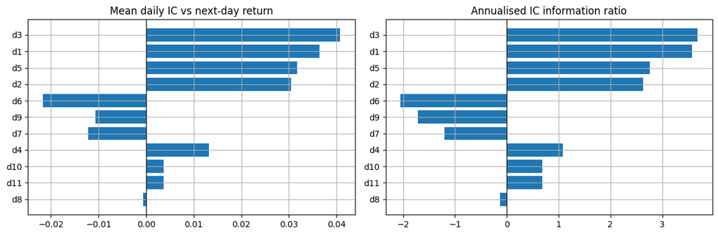

Figure 4: Signal IC strength and annualised IC information ratio

A signal is only useful if its IC is **persistent**, not concentrated in one regime; we therefore inspect the rolling IC through time.

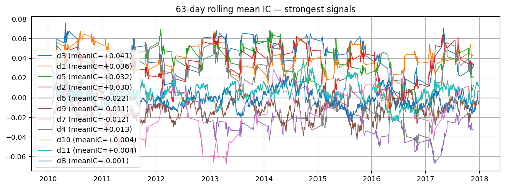

Figure 5: IC stability over time (rolling mean IC)

## 2.8 Distributions and missingness

The raw signals are heavy-tailed, mixed-sign and unevenly populated — which directly motivates the **rank-based (Gaussian-rank) normalisation** used in the modelling section.

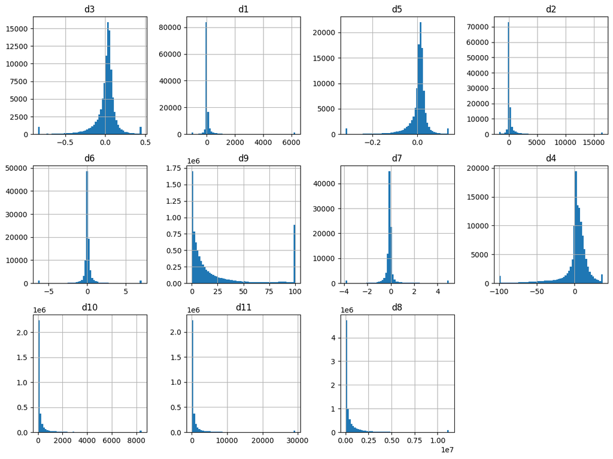

Figure 6: Signal distributions (robust-quantile clipped)

```
signals with NaNs: ['d1', 'd2', 'd3', 'd4', 'd5', 'd6', 'd7']
```

| signal | n_rows | n_nan | pct_missing_val |
| --- | --- | --- | --- |
| d3 | 127266 | 27333 | 21.477 |
| d6 | 127266 | 24992 | 19.638 |
| d7 | 127266 | 24126 | 18.957 |
| d5 | 127266 | 15063 | 11.836 |
| d2 | 127266 | 14636 | 11.5 |
| d1 | 127266 | 4788 | 3.762 |
| d4 | 127266 | 4673 | 3.672 |
| d8 | 8345449 | 0 | 0 |
| d9 | 8159505 | 0 | 0 |
| d10 | 3281273 | 0 | 0 |
| d11 | 3281273 | 0 | 0 |

(a) Missing-value rate per signal

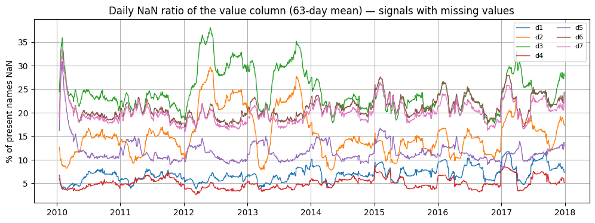

(b)

Figure 7

```
d1 — top 10 securities by NaN %:
             pct_nan
security_id
2238601        0.491
8674501        0.491
22017501       0.491
22417901       0.491
5203601        0.491
8673101        0.491
806001         0.491
809701         0.491
8669001        0.491
2621201        0.491

d2 — top 10 securities by NaN %:
             pct_nan
security_id
8661601        0.491
8660901        0.491
25481401       0.491
1843401        0.491
22417901       0.491
22017501       0.491
2238601        0.491
8863501        0.491
2621201        0.491
8674501        0.491

d3 — top 10 securities by NaN %:
             pct_nan
security_id
5980701        0.491
809201         0.491
3393001        0.491
3394201        0.491
3427401        0.491
8661601        0.491
8660901        0.491
1038801        0.491
3523901        0.491
```

[output cut: 50 more lines]

```
6184001        0.491
6810401        0.491
6879901        0.491
2510001        0.491
6908201        0.491
6935601        0.491
6955501        0.491

d8: no NaNs

d9: no NaNs

d10: no NaNs

d11: no NaNs
```

## 2.9 Collinearity and a redundant signal

Some signal pairs are strongly related; one pair is **perfectly redundant**.

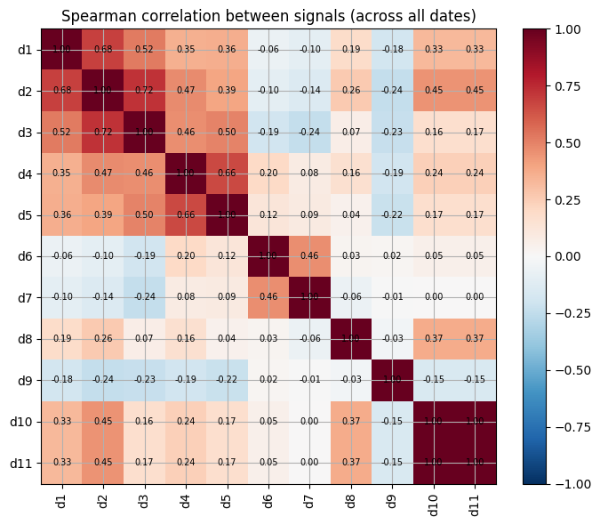

Figure 8: Signal collinearity (Spearman rank correlation)

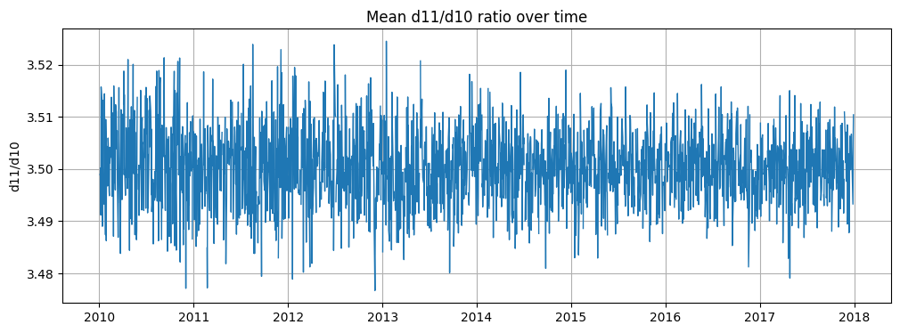

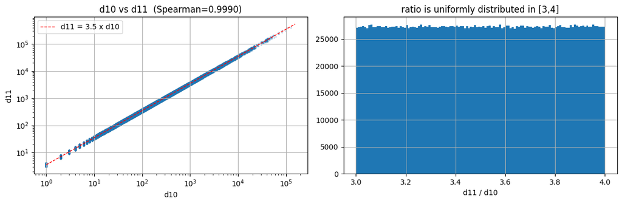

(b)

Figure 9

Table 5: Pearson vs winsorised-Pearson vs Spearman on highly-correlated pairs

| pair | n_both | pearson_raw | pearson_winsor | spearman | skew_a | skew_b |
| --- | --- | --- | --- | --- | --- | --- |
| d1~d2 | 112630 | 0.66 | 0.815 | 0.682 | 28.1 | 47.3 |
| d2~d3 | 99933 | -0 | 0.152 | 0.724 | 48 | 313.5 |
| d4~d5 | 108624 | -0 | 0.549 | 0.657 | -121.5 | 323.2 |

## 2.10 Risk factors

Finally we characterise the six risk factors and confirm the signals are **not** merely disguised factor exposures — a precondition for the risk-factor neutralisation that later drives the Sharpe.

```
risk factor frame: (8800015, 8) | factors: ['rf1', 'rf2', 'rf3', 'rf4', 'rf5', 'rf6']
date range: 20100104 to 20171229
```

```
pct missing per factor:
rf1   0
rf2   0
rf3   0
rf4   0
rf5   0
rf6   0
dtype: float64
```

Table 6: Risk factors rf1–rf6: load and summary

|  | mean | std | min | 25% | 50% | 75% | max |
| --- | --- | --- | --- | --- | --- | --- | --- |
| rf1 | 0.0614702 | 1.16931 | -3.068 | -0.724 | 0.057 | 0.838 | 3.7 |
| rf2 | -0.293111 | 1.16481 | -3.169 | -0.902 | -0.206 | 0.373 | 2.946 |
| rf3 | 0.565605 | 1.27 | -2.893 | -0.461 | 0.264 | 1.588 | 3.034 |
| rf4 | 0.466896 | 1.19519 | -2.818 | -0.405 | 0.281 | 1.216 | 3.278 |
| rf5 | -0.0129885 | 1.11491 | -2.976 | -0.693 | -0.061 | 0.598 | 2.976 |
| rf6 | -0.503807 | 1.28526 | -3.394 | -1.138 | -0.245 | 0.262 | 2.794 |

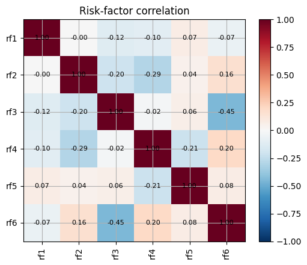

Figure 10: Risk-factor correlation matrix

Table 7: Signal–risk-factor correlations

|  | rf1 | rf2 | rf3 | rf4 | rf5 | rf6 |
| --- | --- | --- | --- | --- | --- | --- |
| d1 | -0.004 | 0.109 | -0.238 | -0.065 | 0.023 | 0.264 |
| d2 | 0.017 | 0.153 | -0.308 | -0.101 | 0.041 | 0.339 |
| d3 | -0.025 | 0.136 | -0.242 | 0.066 | 0.049 | 0.409 |
| d4 | -0.022 | 0.237 | -0.31 | -0.258 | 0.232 | 0.516 |
| d5 | -0.029 | 0.167 | -0.326 | 0.064 | 0.031 | 0.564 |
| d6 | 0.003 | 0.061 | -0.093 | -0.072 | 0.141 | 0.186 |
| d7 | -0.045 | 0.056 | -0.135 | 0.061 | -0.023 | 0.201 |
| d8 | 0.242 | 0.058 | -0.102 | -0.175 | 0.075 | 0.083 |
| d9 | 0.134 | -0.158 | 0.259 | -0.128 | 0.074 | -0.234 |
| d10 | -0.027 | 0.045 | -0.092 | -0.125 | 0.059 | 0.155 |
| d11 | -0.027 | 0.045 | -0.092 | -0.125 | 0.059 | 0.155 |

**TipData-inspection takeaways carried forward**